# Week 6

Let’s then examine the prediction along months

```r
set.seed(123)
# extract the samples into matrix
post_sample2 <- as.matrix(post2, pars =c("a","b", "c","sigma2"))    # combine all chains into one matrix in R workspace
a_dot2=post_sample2[,1]
b_dot2=post_sample2[,2]
c_dot2=post_sample2[,3]
sigma2_dot2=post_sample2[,4]
```

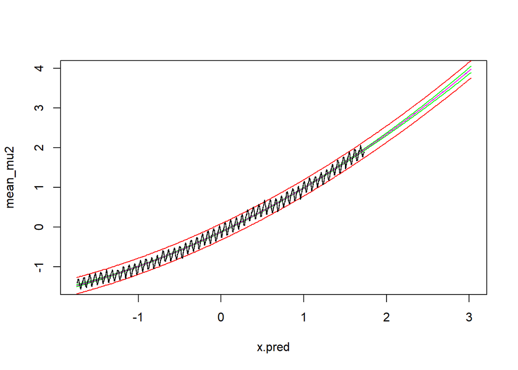

```r
mu2 = matrix(NA,length(x.pred),length(b_dot))
y.tilde2 = matrix(NA,length(x.pred),length(b_dot))

mean_mu2=rep(NA, length(x.pred))
int_mu2 = matrix(NA,length(x.pred),2)

mean_y2=rep(NA, length(x.pred))
int_y2 = matrix(NA,length(x.pred),2)

for (i in 1:length(x.pred)) {
  #mu[i,] = (a + b*x.pred[i])*stdy + my
  mu2[i,] = a_dot2 + b_dot2*x.pred[i] + c_dot2*(x.pred[i]^2)
  mean_mu2[i]=mean(mu2[i,])
  int_mu2[i,] = quantile(mu2[i,],probs=c(0.025,0.975))
  #y_i = mu_i + e_i and e_i ~ N(0,sigma2)
  y.tilde2[i,] =  mu2[i,] + rnorm(length(mu2[i,]), 0, sqrt(sigma2_dot2))
  mean_y2[i]=mean(y.tilde2[i,])
  int_y2[i,] = quantile(y.tilde2[i,],probs=c(0.025,0.975))

}

plot(x.pred,mean_mu2, type="l",col="blue") #posterior mean for mu(x)
lines(x.pred,int_mu2[,1],col="green")
lines(x.pred,int_mu2[,2],col="green") # 95% interval of mu(x)
lines(x.pred,mean_y2, type="l",col="magenta") #posterior mean for y.tilde
lines(x.pred,int_y2[,1],col="red")
lines(x.pred,int_y2[,2],col="red") # 95% interval of y.tilde
lines(x.month,y.month)
points(x.month,y.month, cex=0.2)
```

**Analysis of linear graph**

From the graph we can see that the prediction by the model is closer to the curved shape that we can observe in the original data. A curve like this in a linear regression task usually is a sign that it would be good to check a model using the squares or higher powers of the features in the data.

And then we can do the asked posterior predictive check

```r
pred_sample2 <- post_sample2[sample(nrow(post_sample2),size=20,replace=TRUE),]
post_pred2 <- array(dim=c(20, length(x.month)))
for (i in 1:20){
  for (j in 1:length(x.month)){
    post_pred2[i,j] <- rnorm(1, (pred_sample2[i, 'a'] + pred_sample2[i, 'b'] * x.month[j] + pred_sample2[i, 'c'] * (x.month[j]^2)), pred_sample[i, 'sigma2'])
  }
}
#for (i in 1:20){plot(x.month, post_pred2[i,])}
```

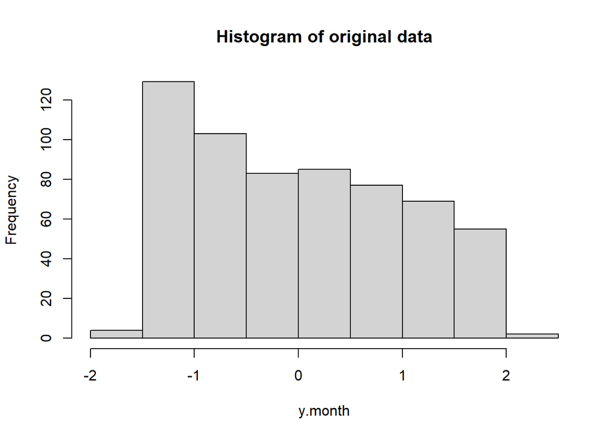

```r
hist(y.month, main="Histogram of original data")
```

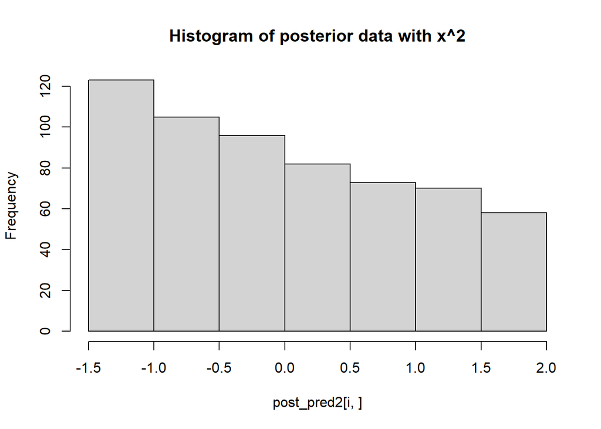

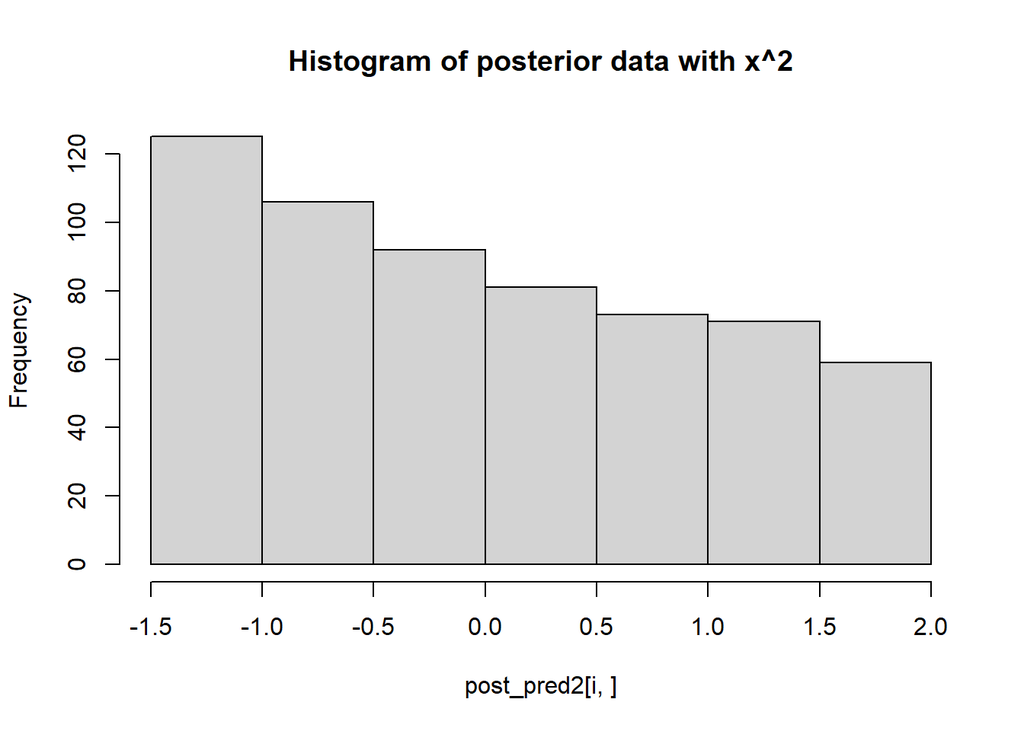

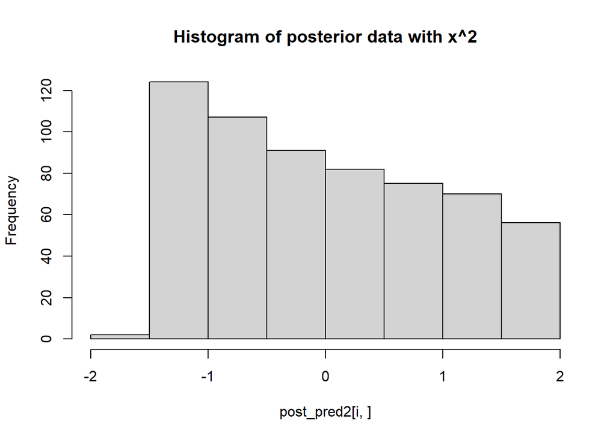

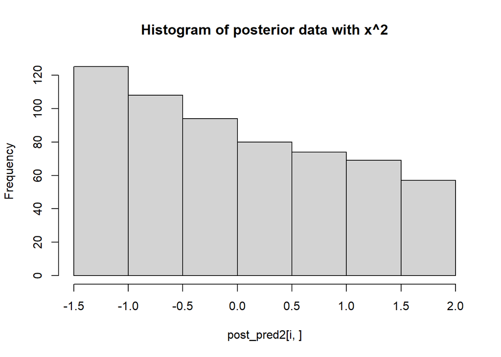

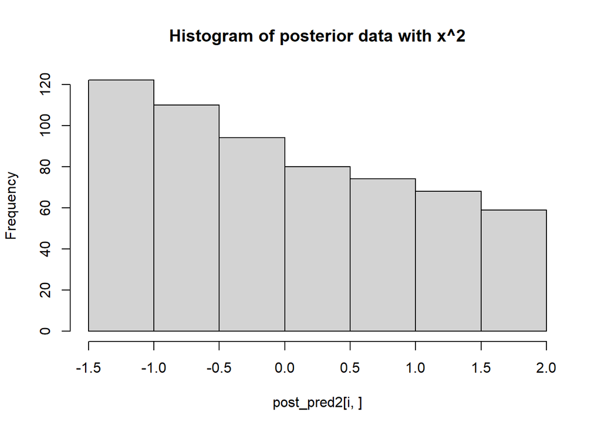

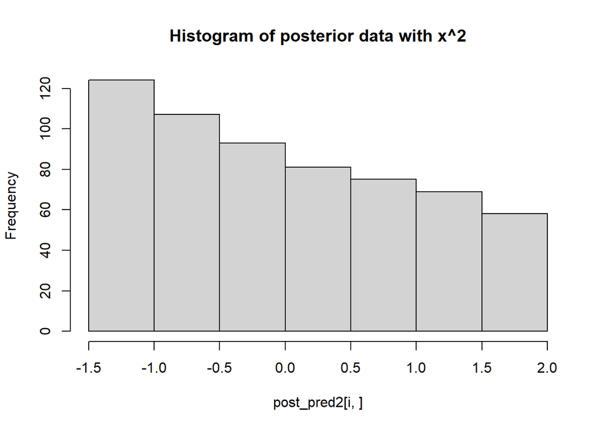

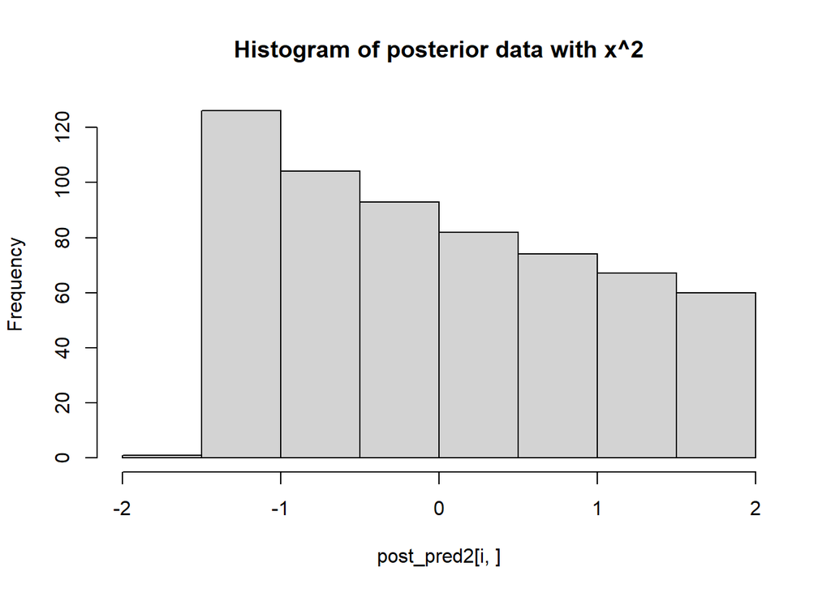

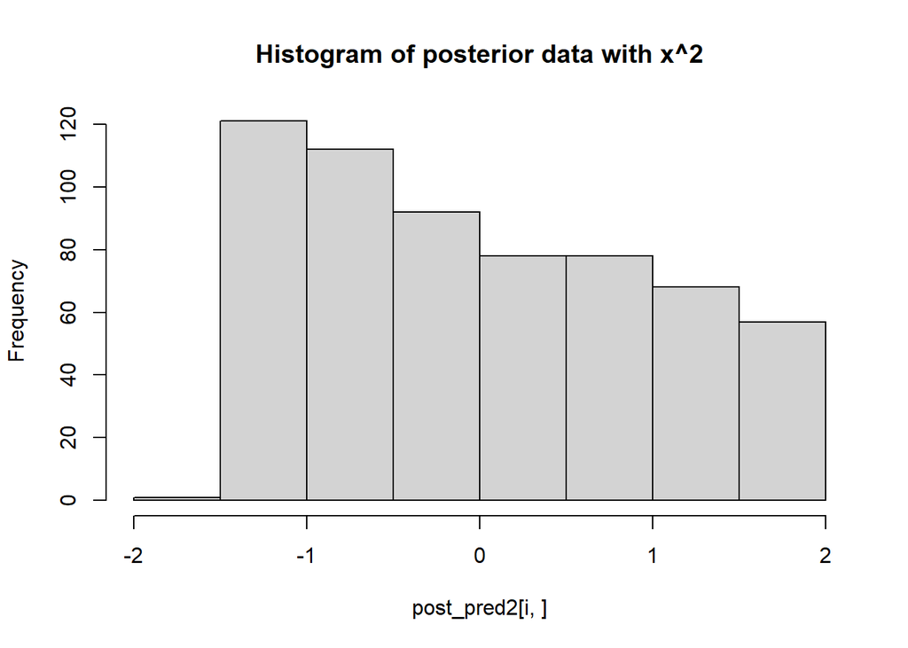

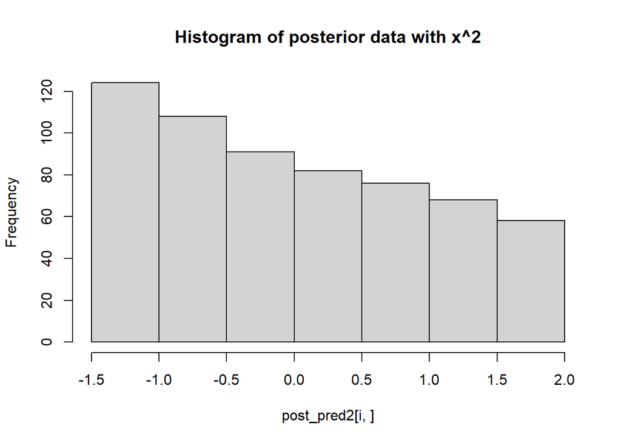

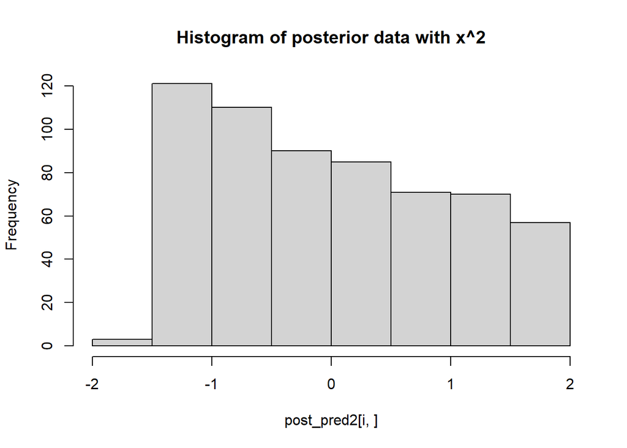

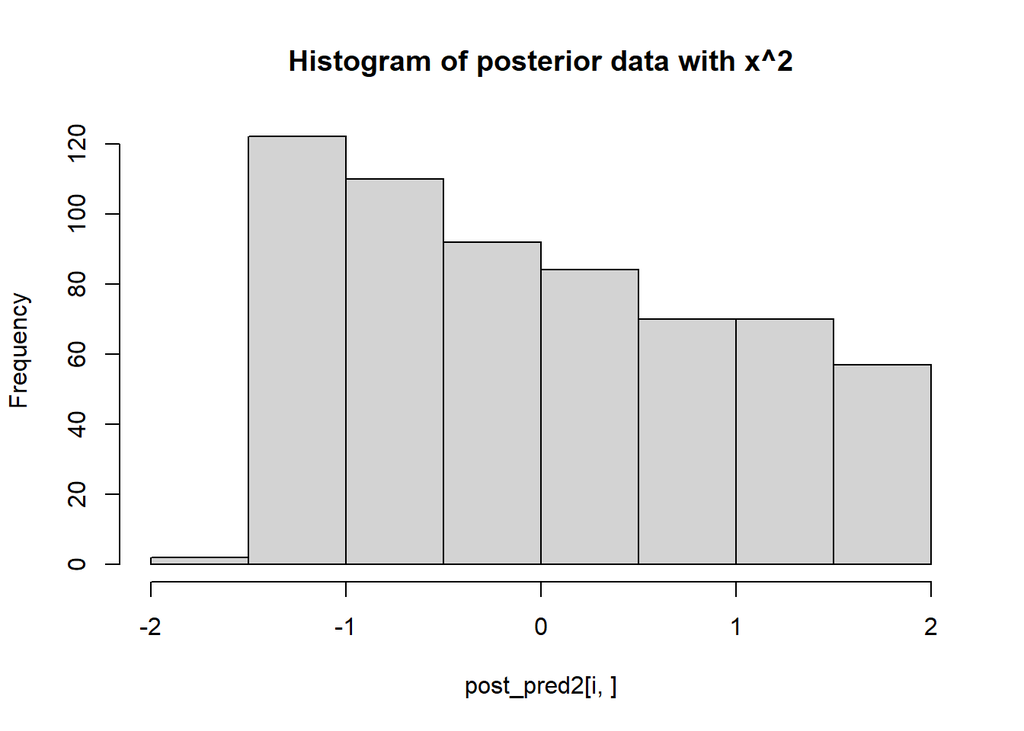

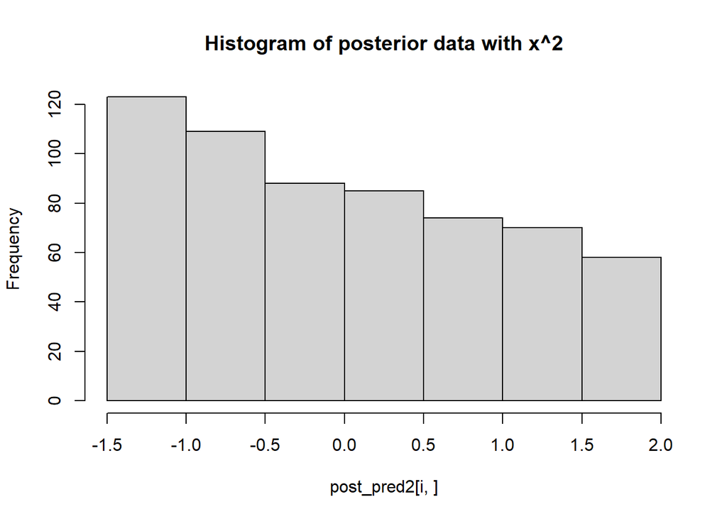

[8 more figures not shown]

```r
for (i in 1:20){hist(post_pred2[i,], main="Histogram of posterior data with x^2")}
```

**Analysis**

We see that with this model, the posterior predictive samples are much more similar to the original data. The samples are more concentrated at lower values, exactly like in the original data, and as can be expected with a linear model of with the square of a feature.

## Posterior predictive comparison

Let’s next compare the models’ cababilities to predict unseen data. For this we divide the data into training and test sets, infer the model parameters with the former and evaluate models performance in predicting the latter

Split the data into training and test sets so that you put every other data point into training and every other into test (we could do random split as well).

```r
x.month.train <- x.month[seq(1, length(x.month), 2)]
x.month.test <- x.month[seq(2, length(x.month), 2)]
y.month.train <- y.month[seq(1, length(y.month), 2)]
y.month.test <- y.month[seq(2, length(y.month), 2)]
```

Sample from the posterior distribution of the first model ($\mu=a+bx$) conditional on the training data and check for convergence

```r
set.seed(123)
data <- list (N=length(x.month.train), y=y.month.train, x=x.month.train)
post3=stan(model_code=mauna_loa_c02_model,data=data,warmup=500,iter=2000,chains=4,thin=1,control = list(adapt_delta = 0.8,max_treedepth = 10))

# Check for convergence, see PSRF (Rhat in Stan)
print(post3,pars=c("a","b","sigma2"))
```

```
## Inference for Stan model: anon_model.
## 4 chains, each with iter=2000; warmup=500; thin=1;
## post-warmup draws per chain=1500, total post-warmup draws=6000.
##
##        mean se_mean   sd  2.5%   25%  50%  75% 97.5% n_eff Rhat
## a      0.00       0 0.01 -0.02 -0.01 0.00 0.01  0.02  6211    1
## b      0.99       0 0.01  0.97  0.98 0.99 0.99  1.01  7153    1
## sigma2 0.02       0 0.00  0.02  0.02 0.02 0.02  0.03  4318    1
##
## Samples were drawn using NUTS(diag_e) at Mon Dec 12 18:59:04 2022.
## For each parameter, n_eff is a crude measure of effective sample size,
## and Rhat is the potential scale reduction factor on split chains (at
## convergence, Rhat=1).
```

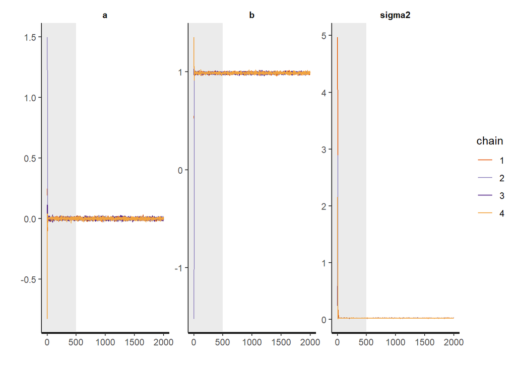

```r
#print(post)
plot(post3, pars=c("a","b","sigma2"),plotfun= "trace", inc_warmup = TRUE)
```

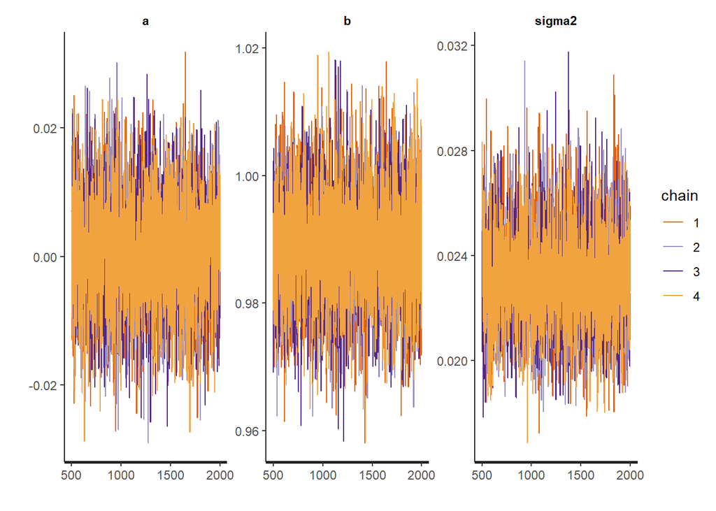

```r
plot(post3, pars=c("a","b","sigma2"), plotfun= "trace", inc_warmup = FALSE)
```

The Rhats are good at 1 and visually one can see that the chains have converged.

Sample from the posterior distribution of the second model ($\mu=a+bx+cx^2$) conditional on the training data and check for convergence

```r
set.seed(123)
post4=stan(model_code=mauna_loa_c02_model2,data=data,warmup=500,iter=2000,chains=4,thin=1,control = list(adapt_delta = 0.8,max_treedepth = 10))

# Check for convergence, see PSRF (Rhat in Stan)
print(post4,pars=c("a","b","c", "sigma2"))
```

```
## Inference for Stan model: anon_model.
## 4 chains, each with iter=2000; warmup=500; thin=1;
## post-warmup draws per chain=1500, total post-warmup draws=6000.
##
##         mean se_mean   sd  2.5%   25%   50%   75% 97.5% n_eff Rhat
## a      -0.12       0 0.01 -0.14 -0.13 -0.12 -0.12 -0.10  3544    1
## b       0.99       0 0.01  0.98  0.99  0.99  0.99  1.00  5258    1
## c       0.12       0 0.01  0.11  0.12  0.12  0.13  0.13  3735    1
## sigma2  0.01       0 0.00  0.01  0.01  0.01  0.01  0.01  3826    1
##
## Samples were drawn using NUTS(diag_e) at Mon Dec 12 18:59:41 2022.
## For each parameter, n_eff is a crude measure of effective sample size,
## and Rhat is the potential scale reduction factor on split chains (at
## convergence, Rhat=1).
```

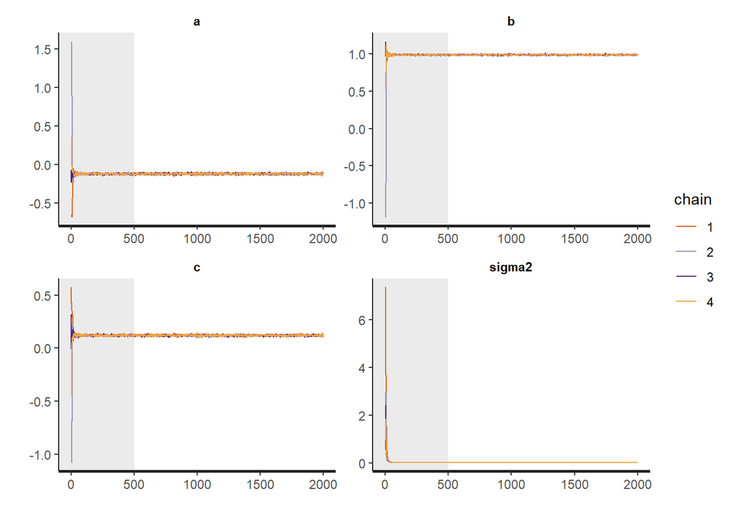

```r
#print(post)
plot(post4, pars=c("a","b","c", "sigma2"),plotfun= "trace", inc_warmup = TRUE)
```

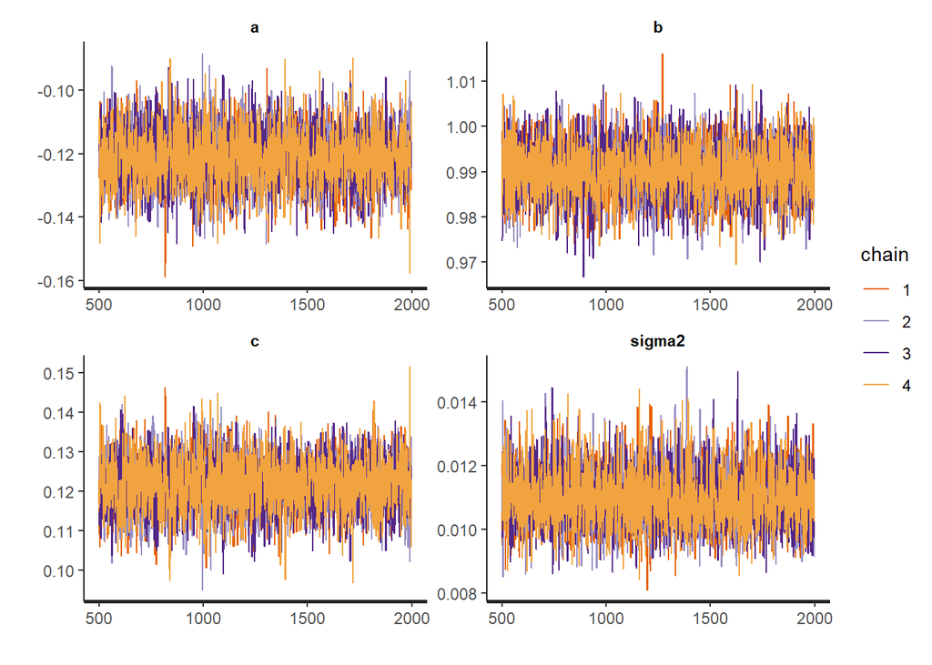

```r
plot(post4, pars=c("a","b","c", "sigma2"), plotfun= "trace", inc_warmup = FALSE)
```

Again, Rhats and convergence looks fine.

Now we can calculate point-wise posterior predictive log density and RMSE at test locations

Starting with RMSE:

```r
post_sample3 <- as.matrix(post3, pars =c("a","b","sigma2"))
a3 <- post_sample3[, 'a']
b3 <- post_sample3[, 'b']
sigma23 <- post_sample3[, 'sigma2']
```

```r
mu3 <- array(dim = c(length(x.month.test)))
for (i in 1:length(x.month.test)){
  mu3[i] <- mean(a3 + b3*x.month.test[i])
}
```

```r
RMSE <- sqrt(sum((y.month.test - mu3 )^2))
RMSE
```

```
## [1] 2.616689
```

```r
post_sample4 <- as.matrix(post4, pars =c("a","b","c", "sigma2"))
a4 <- post_sample4[, 'a']
b4 <- post_sample4[, 'b']
c4 <- post_sample4[, 'c']
sigma24 <- post_sample4[, 'sigma2']

mu4 <- array(dim = c(length(x.month.test)))
for (i in 1:length(x.month.test)){
  mu4[i] <- mean(a4 + b4*x.month.test[i] + c4*(x.month.test[i]^2))
}

RMSE2 <- sqrt(sum((y.month.test - mu4 )^2))
RMSE2
```

```
## [1] 1.808179
```

**Analysis of RMSE** The RMSE of the squared, second model is at $\approx1.81$ lower than the RMSE for the first linear model at $\approx2.62$, which indicates that the second model ($mu = a+b*x+c*x^2$) produces predictions that were closer to the measured values. The sum of the squares of differences between the predictions and the actual values is smaller.

Then let’s have a look at the log predictive density:

```r
loglik1 <- array(dim = c(length(x.month.test)))
for (i in 1:length(x.month.test)){
  loglik1[i] <- log(mean(dnorm(y.month.test[i], a3 + b3*x.month.test[i], sigma23)))
}
sum(loglik1)
```

```
## [1] -3186.7
```

```r
loglik2 <- array(dim = c(length(x.month.test)))
for (i in 1:length(x.month.test)){
  loglik2[i] <- log(mean(dnorm(y.month.test[i], a4 + b4*x.month.test[i] + c4*(x.month.test[i]^2), sigma24)))
}
sum(loglik2)
```

```
## [1] -5926.257
```

```r
#y.month.test
```

**Analysis of predictive log likelihood**

The result of these calculations are a bit unclear to me. As I understand it, a lower log likelihood would imply a worse model, so in that case, this test would show that the model with a squared feature would not be the better model. I therefore draw the conclusion that either there is something wrong with the calculation (which would be strange, as I attended the exercise session specifically to ask for help for this, so it would be confusing if I wouldn’t have received correct guidance), or then I am incorrect in interpreting the predictive log likelihood.